# A meta-analysis fo the multi-trophic effects of grazing

2018

### Grazing effects are multi-trophic through mediating plant composition: a meta-analysis

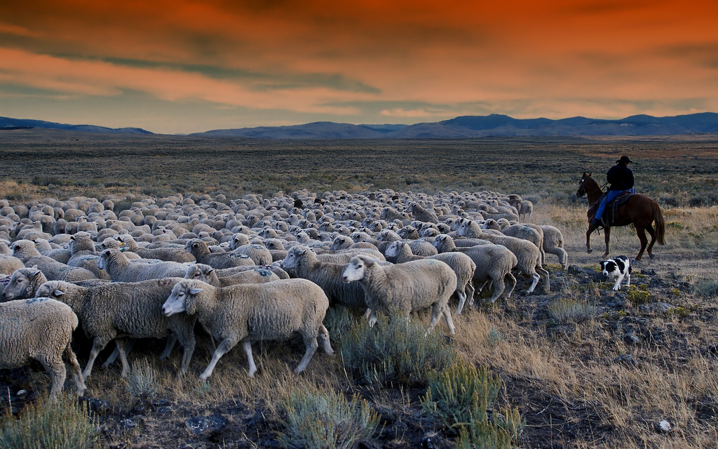

[Alessandro Filazzola](http://www.filazzola.info/), Batbaatar Amgaa, Charlotte Brown, Issac Heida, Jessica Grenke, Margarete Dettlaff, Tan Bao, & [JC Cahill](https://grad.biology.ualberta.ca/cahill/)

```r
library(tidyverse)
library(PRISMAstatement)
```

### Purpose

Conduct a meta-analysis of the literature testing the indirect effects of grazing on animal taxa’s through the direct effects on the plant community.

### Search Terms

A systematic literature search was conducted using Web of Science for all emperical research articles. The review will include all studies globally. The intended purpose of this search is to capture all articles that have documented grazing either along a gradient (e.g. different frequencies or intensity) or presence/absence (e.g. excluded, ungrazed, or retired ranch lands). We condcuted two separate searches to capture studies that tested gradients and studies that compared grazing to ungrazed treatments. Duplicate articles between the searches were removed. We also intentionally excluded terms that resulted in articles not relevant to the purpose of this study including: review, synthesis, policy, social, carbon, and fish. The search terms that used were:

**Search A** `graz* OR livestock` **AND** `exclosure* OR exclusion OR exclude* OR ungrazed OR retire* OR fallow*`

**Search B** `grazing intensity OR grazing gradient OR stocking rate OR rotation* grazing`

### Timeline

| date | task |
| --- | --- |
| Nov 9 | Establish search terms to be used in the meta-analysis |
| Nov 12 | Compile list of journal artcles and sub-divide for each researcher |
| Nov 14 | Begin reviewing papers and extracting data |
| Jan 28 | Complete data extraction from papers |
| Feb 11 | Complete preliminary analysis and set structure for MS |
| Feb 25 | Settle on analyses to be used and begin writing manuscript |
| March 11 | Complete first draft of MS and pass to co-authors |
| March 25 | Comments passed back on draft |
| April 2 | Complete revisions and submit to journal |

### Literature Review - 1. Search

### Revise list

```r
search1.1 <- read.csv("data/WOS-lit.csv")
search1.2 <- read.csv("data/WoSPart3-July_4_2018.csv")
net.difference <- anti_join(search1.2, search1.1, by = "DOI")
net.difference <- net.difference %>% select(Title, DOI) #to simplify for a look
nrow(net.difference) #count of number of differences from consecutive search

## 182 papers to be added by including revised terms
## Select those articles and join with other dataset
net.difference <- anti_join(search1.2, search1.1, by = "DOI")

updated.search <- rbind(search1.1, net.difference)

#write.csv(updated.search, "data/WOS-lit.updated.csv")
```

[output not shown]

### Literature Review - 2. Sort

This steps includes a. checking for duplicating, b. reviewing each instance for relevancy, c. consistently identifying and documenting exclusion criteria. Outcomes include a list of publications to be used for synthesis, a library of pdfs, and a PRISMA report to ensure the worflow is transparent and reproducible. Papers were excluded with the following characteristics:

- Not emperical study (e.g. review, book chapter)
- Irrelevant categories (e.g. political science, law, sports tourism, art)